# Homework 6

Frank Marino

March 1, 2026

## Load Libraries

```r
# Load any R Packages you may need
rm(list = ls())
library(mosaic)
library(tidyverse)
library(treemap)
library(devtools)
install_github("timelyportfolio/d3treeR")
library(d3treeR)
library(dplyr)
```

## Load Data

The following exercises use the `airbnb_boston.csv` data set. Download the .csv file from our Canvas course and load the file into R to complete this assignment. Call this data `airbnb_boston`. Omit null values and then pare down the data set to only include the columns of `price`, `neighbourhood`, and `property_type`.

This assignment uses the `treemap` and `d3Tree` packages.

```r
# Load Data into R
airbnb_boston <- read_csv("airbnb_boston.csv")
airbnb_boston = airbnb_boston %>%
  na.omit()
airbnb_boston = airbnb_boston %>%
  select(price, neighbourhood, property_type)
```

## Exercise 1

In this exercise, you will focus on creating Tree Maps in R/RStudio.

### (a)

Using `treemap()`, create a tree map that groups the `airbnb_boston` data by Property Type -> Neighborhood -> Price. This tree map should be static. Save this tree map in a named variable `airbnb_boston_treemap`.

```r
airbnb_boston_treemap <- treemap(
  airbnb_boston,
  index = c("property_type", "neighbourhood"),
  vSize = "price",
  type = "index",
  palette = "Set3",
  title = "Airbnb Boston Treemap"
)
```

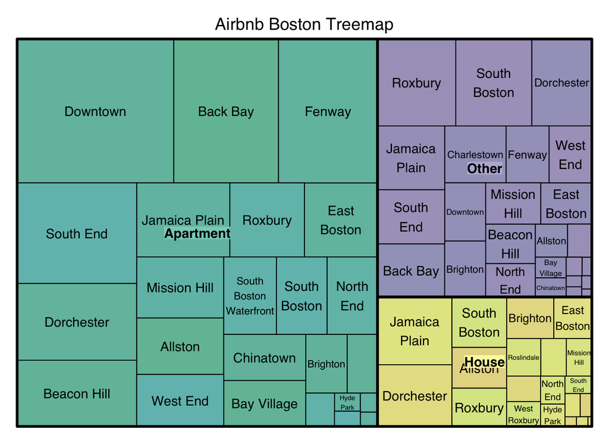

### (b)

Using `d3tree()`, convert your static tree map into an interactive tree map.

```r
d3tree(airbnb_boston_treemap, rootname = "Airbnb Boston Interactive Treemap")
```

[interactive chart not shown]

## Exercise 2

In this exercise, you will focus on creating Tree Maps in Canva.

### (a)

Using the loaded `airbnb_boston` data, you will filter the data set to include eight neighborhoods. Using the code chunk below, filter the `airbnb_boston` data set to eight of the neighborhoods and call this filtered data set `airbnb_boston_filtered`:

- Allston
- Back Bay
- Bay Village
- Beacon Hill
- Brighton
- Charlestown
- Chinatown
- Dorchester
- Downtown
- East Boston
- Fenway
- Hyde Park
- Jamaica Plain
- Leather District
- Longwood Medical Area
- Mattapan
- Mission Hill
- North End
- Roslindale
- Roxbury
- South Boston
- South Boston Waterfront
- South End
- West End
- West Roxbury

### Filter Data

*NOTE: Be sure to match exactly the spelling and case sensitivity when selecting categories or your data set might not filter properly!*

```r
keep_neigh <- c(
  "East Boston", "Back Bay", "South Boston", "North End",
  "Fenway", "Chinatown", "Beacon Hill", "Downtown"
)

airbnb_boston_filtered <- airbnb_boston %>%
  filter(neighbourhood %in% keep_neigh)
```

###(b) You are tasked with creating an interactive tree map using the template found in Canva. Your tree map should be the same variables as Exercise 1: Property Type -> Neighborhood -> Price. 1. Create a Canva Presentation with **ONE** slide. 2. Click on **ELEMENTS** on the left-hand menu. 3. Scroll down and click on *See all* next to the header for **CHARTS** 4. Under **INTERACTIVE CHARTS**, click on the second option for **Treemap Chart**.

You may need to perform some analysis in R in order to get the data required to create the tree map. Perform any additional R analysis here:

### R Analysis

*Perform all your R analysis here. Use comments to break-out the different elements you are going to include.*

```r
airbnb_boston_summary <- airbnb_boston_filtered %>%
  group_by(neighbourhood, property_type) %>%
  summarise(
    mean_price = mean(price, na.rm = TRUE),
    n_listings = n(),
    .groups = "drop"
  ) %>%
  arrange(neighbourhood, desc(mean_price))

airbnb_boston_summary
```

| neighbourhood | property_type | mean_price | n_listings |
| --- | --- | --- | --- |
| Back Bay | Apartment | 235.2837 | 141 |
| Back Bay | Other | 218.1944 | 36 |
| Back Bay | House | 150.2500 | 4 |
| Beacon Hill | Other | 239.5556 | 18 |
| Beacon Hill | Apartment | 189.3804 | 92 |
| Beacon Hill | House | 122.5000 | 2 |
| Chinatown | Other | 260.4000 | 5 |
| Chinatown | Apartment | 160.1154 | 52 |
| Chinatown | House | 85.0000 | 1 |
| Downtown | House | 244.0000 | 1 |
| Downtown | Other | 218.4583 | 24 |
| Downtown | Apartment | 191.3398 | 259 |
| East Boston | Apartment | 141.7619 | 84 |
| East Boston | Other | 125.5405 | 37 |
| East Boston | House | 105.4242 | 33 |
| Fenway | Apartment | 246.7323 | 127 |
| Fenway | Other | 215.3200 | 25 |
| Fenway | House | 155.0000 | 5 |
| North End | House | 499.3333 | 3 |
| North End | Other | 191.6842 | 19 |
| North End | Apartment | 186.6522 | 46 |
| South Boston | House | 242.3200 | 25 |
| South Boston | Other | 198.8904 | 73 |
| South Boston | Apartment | 148.4828 | 58 |

```r
canva_treemap_data <- airbnb_boston_summary %>%
  transmute(
    PropertyType = property_type,
    Neighbourhood = neighbourhood,
    Value = mean_price
  )

write_csv(canva_treemap_data, "canva.csv")
```

```r
airbnb_boston_tableau <- airbnb_boston %>%
  group_by(neighbourhood, property_type) %>%
  summarise(
    mean_price = mean(price, na.rm = TRUE),
    n_listings = n(),
    .groups = "drop"
  ) %>%
  arrange(neighbourhood, desc(mean_price))
write_csv(airbnb_boston_tableau, "tableau_data.csv")
```

### (b)

Embed your Canva Presentation Here:

[interactive chart not shown]

[Airbnb Boston Interactive Treetop](https://www.canva.com/design/DAHCiUL2qZs/OGXl1PtabivxWlzgsFeh6Q/view?utm_content=DAHCiUL2qZs&utm_campaign=designshare&utm_medium=embeds&utm_source=link) by Frank Marino

### (c)

Trouble embedding? No worries! Provide your Canva link here as a back-up:

## Exercise 3

In this exercise, you will focus on creating Tree Maps in Tableau. The last exercise will use the `airbnb_boston.csv` data set and Tableau.

### (a)

You are tasked with creating a Tableau Story that has **ONLY** two points:

1. Story Point 1: A home page dashboard panel with at least 2 visualizations for potential travelers to *view* **AND** *interact* with to make a decision on where they should stay when they visit Boston.
2. Story Point 2: A **tree map** that uses the identical variables above: property_type,neighborhood, and color coded by price.

### (b)

After you create your Tableau story, save your work to Tableau Public and then embed your code below directly into your HTML page. **Be sure to add a lot of blank space as the embed needs space to render this as HTML code.**

**Copy your Tableau Embed Code Here**

[figure not shown]

### (c)

Trouble embedding? No worries! Provide your Tableau Public Dashboard link here as a back-up:

URL Link to Tableau Dashboard: Frank Marino- Homework 6

## All done!

Knit the completed R Markdown file as a HTML document (click the “Knit” button at the top of the script editor window) and upload it to the submission portal on Canvas.